# Metcalf_Data_Replication_Assignment

Cat Metcalf

2023-10-26

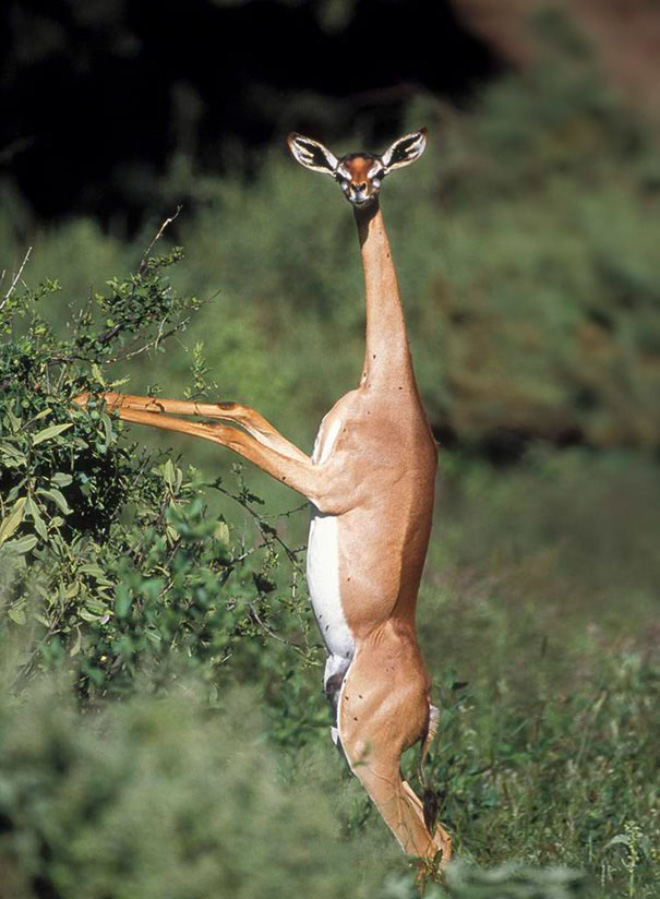

Silly Standing Gazelle!

# Data Replication Assignment

This replication assignment is based on an article by Munro et al. 2018 that discusses the development of agriculture through human management in the Southern Levant. A more thorough background is provided below!

## Background

The goal of Munro and colleague’s analysis is to determine the change in wild Gazelle abundances and how they correlate with the rise of domestic taxa in the Southern Levant. They are expecting a gradual trade-off between wild game (Gazelle) and presently domestic taxa (Goats, sheep, pigs, etc.). This would be shown by relative abundances that show intensive hunting (aka increase in smaller taxa) in active cultural periods prior to this trade-off and then reverse as soon as trade-off begins. Their chronological sequence (for my figure) follows the Kebaran period to the Middle Pre-Pottery Neolithic B. The figure I have chosen specifically, Figure 2a, takes the proportion of Gazelle (calculated from NISP by period/total NISP of Gazelle) and traces the average of this proportion over 7 periods to show whether this trade-off effect on wild taxa takes place. Their results in their Figure 2a show that the proportion of Gazelle increased as intensive hunting occurred, since the gazelle were of the smallest hunted ungulates, and then went back to the level it was and slightly lower, showing that this food source was replaced by something else, likely the domesticated taxa.

## Supplementary NISP data

First we must load in the packages we need for analysis and data set that provides the supplementary data:

```r
library(curl) #lets us load dataset
library(tidyverse) #access different arrange and mutate functions
```

```r
library(ggplot2) #allows us to plot data
library(dplyr) #further uses of data manipulation packages

f <- curl("https://raw.githubusercontent.com/cattuccino/Metcalf-data-replication-assignment/main/AN588%20DataRep%20SuppData%202.csv")
S3 <- read.csv(f, header = TRUE, sep = ",", stringsAsFactors = FALSE)
head(S3) #dataset we are using to form the figure and take descriptive statistics
```

```
##             SITE PERIOD Gazella Cervidae Capra Bos Sus Total X.Gazella
## 1      Yiftah'el  MPPNB    1974       19   182 304 383  2862      69.0
## 2 Kfar ha Horesh  MPPNB     568        5   166  77  50   866      65.6
## 3          Motza  MPPNB     289        1    96  18  60   464      62.3
## 4          Motza  EPPNB    2881        5   201 100 358  3545      81.3
## 5        Hatoula   PPNA    1785       21    23  31  13  1873      95.3
## 6        Hatoula   LNAT    4512      113    45  76  67  4813      93.7
```

X.Gazella = Proportion of Gazelle, which will be our y while PERIOD is our x.

## Taking the mean and quantiles of each point

In order to do this we need to group each Gazella proportion by its associated period and then take the mean of all of those proportions.

```r
gazella_calc <- summarise(group_by(S3, PERIOD), mean(X.Gazella)) #it groups the output (X.Gazella) by Period from the dataset and then summarises these in a table for us to look at the data we will use for the next figure
gazella_calc
```

```
## # A tibble: 12 × 2
##    PERIOD `mean(X.Gazella)`
##    <chr>              <dbl>
##  1 ENAT                91.0
##  2 EPPNB               81.3
##  3 GKEB                70.6
##  4 KEB                 72.1
##  5 LNAT                92.3
##  6 MP1/2               57.1
##  7 MP3                 46.2
##  8 MP4                 39.2
##  9 MP5/6               59.1
## 10 MPPNB               65.6
## 11 PPNA                95.3
## 12 UP                  80.3
```

## Replication of Figure 2a, p. 5

Plots the relative abundance indices (mean of data for each Period) and associated quantiles (2 Descriptive analyses).

Uses supplementary data: Figure 2a uses Table S3, so this is the dataset we use, but it requires some manipulating to form their figure.

For this plot we have to: -take a mean of the data for each period for proportion of Gazelle to show the average proportion for each period -take the confidence interval based on quantiles of that mean to show the distribution, a wider range would show there is a wider difference in proportion of Gazelle per period -plot these means with their quantiles to show the change over chronological period in the proportion of Gazelle.

First we have to make a plot of the data:

```r
gazella_med <-
  S3 |> #some general piping so we can organize the data from S3 as they do
  select("SITE", "PERIOD", "X.Gazella") |> #to keep our data together
  filter(PERIOD == "KEB" | PERIOD == "GKEB" |
           PERIOD == "ENAT" | PERIOD == "LNAT" |
           PERIOD == "PPNA" | PERIOD == "EPPNB" |
           PERIOD == "MPPNB") |> #selects for the particular periods they plot for
  arrange("PERIOD")
```

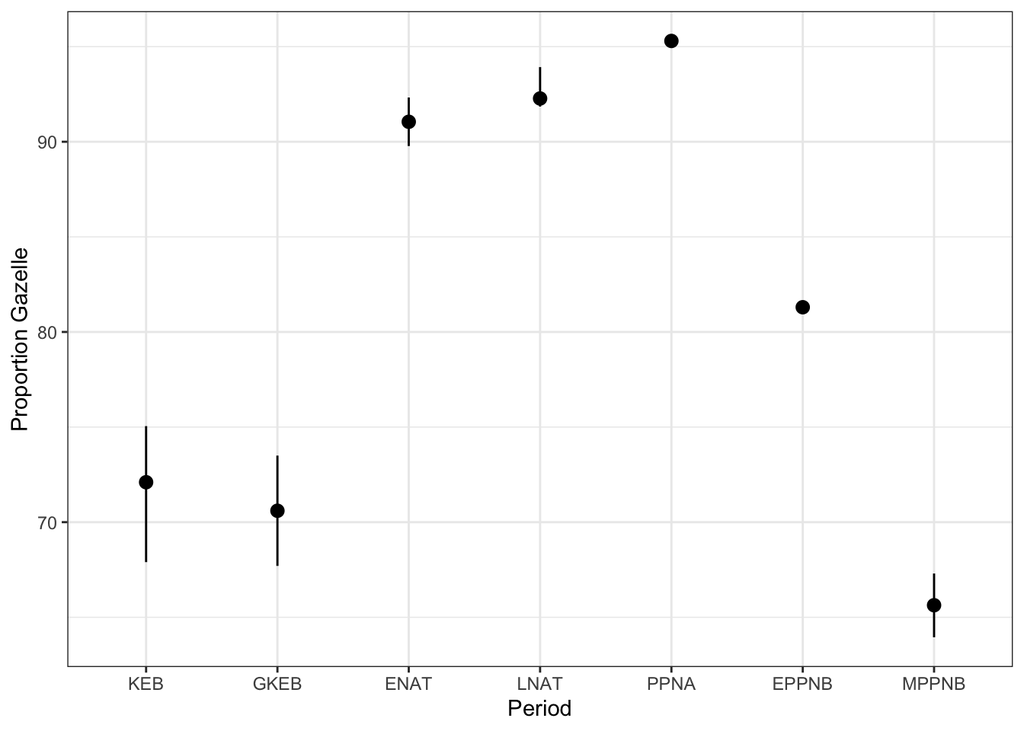

```r
gazella_med |>
  ggplot(data = gazella_med,
  mapping = aes(x = as.factor(PERIOD), y = X.Gazella)) + #making a plot comparing Period to proportion of Gazelle
  geom_pointrange(stat = "summary",
                  fun = mean,
                  fun.min = function(z){quantile(z, 0.25)},
                  fun.max = function(z){quantile(z, 0.75)}) + #this part of the calculation I found on a website (cited below), which takes the mean of each point while applying a confidence interval around each mean taken to show the range of distribution it could be (seen if you do not take the means and simply plot the values)
  labs(y = "Proportion Gazelle", x = "Period") + #labeling x and y axes
  scale_x_discrete(limits = c("KEB", "GKEB", "ENAT", "LNAT", "PPNA", "EPPNB", "MPPNB")) + #puts the periods in the order they have them in (chronological)
  theme_bw()
```

In comparison to their figure:

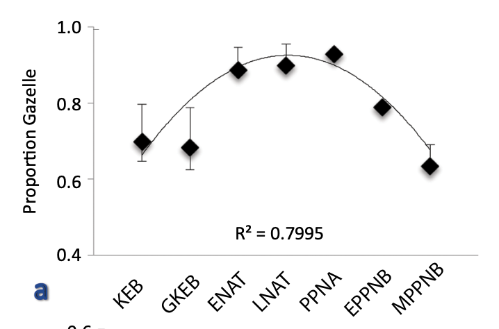

Munro et al. 2018 Figure

Mean and quantile calculation within plot source: https://stackoverflow.com/questions/41077199/how-to-use-r-ggplot-stat-summary-to-plot-median-and-quartiles .

## Reflection

### 1. Lack of a Regression Line

You will notice there is not a line like there is in their figure. This was because they inserted a “regression line” that appeared to only follow their points to further support their argument that there is a change. When applying this in my code, it did not work the same way because Period does not have any associated numerical values but is categorical with labels, so a line was not drawn because you are not exactly comparing these things you are simply tracing a change over time. I think either figure works in showing their point, but a line simply is not necessary here because it is clear there is change over time. Another reflective note is their choice to take the mean of a the proportion of Gazelle, which seems to really constrict their data for their figure and if you plot without this change in the data (shown below with only the mean w/ quantile chunk removed), you still see the change and it actually helps represent the distribution in data a lot more. It may be useful to show all these points to actually discuss by site each point and what may contribute to these differences.

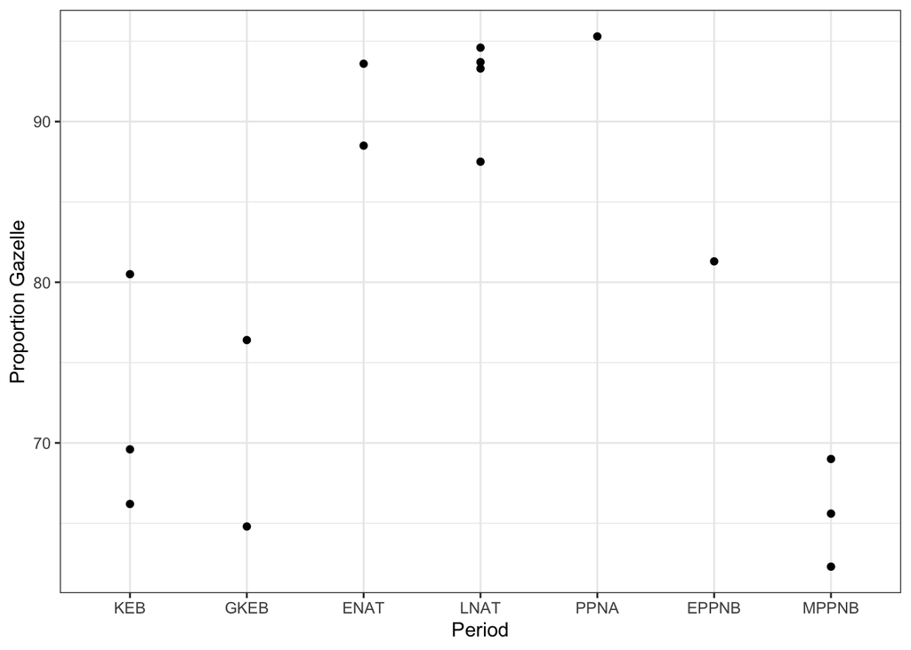

```r
gazella_med |>
  ggplot(data = gazella_med,
  mapping = aes(x = as.factor(PERIOD), y = X.Gazella)) + #making a plot comparing Period to proportion of Gazelle
  geom_point() +
  labs(y = "Proportion Gazelle", x = "Period") + #labeling x and y axes
  scale_x_discrete(limits = c("KEB", "GKEB", "ENAT", "LNAT", "PPNA", "EPPNB", "MPPNB")) + #puts the periods in the order they have them in (chronological)
  theme_bw()
```

### 2. Testing if Data Correlation is Significant

Also in my own figure I am lacking the inferential statistic that the regression line would have offered, but I have chosen to replace this with a chi-squared statistic to see if the changes in gazella proportion actually correlates with period. Using the gazella_med dataframe, we will test gazella proportion by period:

```r
chisq.test(gazella_med$PERIOD, gazella_med$X.Gazella, correct = FALSE)
```

```
##
##  Pearson's Chi-squared test
##
## data:  gazella_med$PERIOD and gazella_med$X.Gazella
## X-squared = 96, df = 90, p-value = 0.3131
```

We get an insignificant p-value as we can see with p>0.05, inidcating this association done by the authors may not be entirely accurate in reflecting the data.